# Home vs Away Tactical Setup Analysis

Study Group 10: Neha, Ediz, Amy, Philippe, Sarah, Kinson

# 1 **Introduction**

This report explores the question:

> **How do home vs away tactical setups differ across Europe’s Top 5 leagues?**

We investigate:

- Formation choices
- Defensive structure over time
- Attacking vs defensive behaviour
- Starting XI structural balance
- Overall thematic patterns

# 2 **Formation Comparison (Graph 1)**

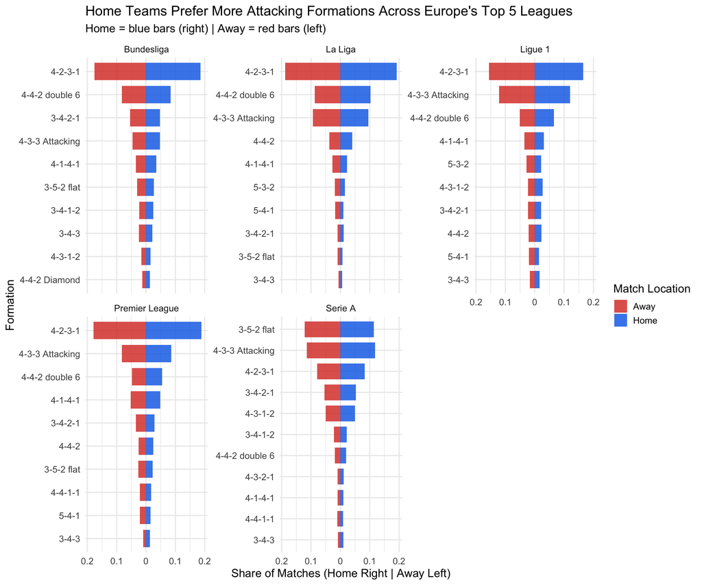

```r
# Filtering only top 5 leagues & reshape
formations_long <- games %>%
  filter(competition_id %in% top5,
         competition_type == "domestic_league") %>%
  pivot_longer(
    cols = c(home_club_formation, away_club_formation),
    names_to = "venue",
    values_to = "formation"
  ) %>%
  mutate(
    is_home = if_else(venue == "home_club_formation", "Home", "Away")
  ) %>%
  filter(!is.na(formation))

# Computing formation frequency per league
formation_freq <- formations_long %>%
  count(competition_id, formation, sort = TRUE)

# Keeping Top 10 formations per league
top_formations <- formation_freq %>%
  group_by(competition_id) %>%
  slice_max(n, n = 10) %>%
  ungroup()

formations_filtered <- formations_long %>%
  inner_join(top_formations, by = c("competition_id", "formation"))

# Compute share per formation
formation_share <- formations_filtered %>%
  group_by(competition_id, is_home, formation) %>%
  summarise(n = n(), .groups = "drop") %>%
  group_by(competition_id) %>%
  mutate(pct = n / sum(n)) %>%
  ungroup()

# Ordering formations by home usage
formation_order <- formation_share %>%
  filter(is_home == "Home") %>%
  group_by(competition_id) %>%
  arrange(desc(pct)) %>%
  mutate(order = row_number())

formation_share <- formation_share %>%
  left_join(formation_order %>% select(competition_id, formation, order),
            by = c("competition_id", "formation"))

# Plot
ggplot(formation_share,
       aes(x = reorder_within(formation, pct, competition_id),
           y = ifelse(is_home == "Home", pct, -pct),
           fill = is_home)) +
  geom_col(width = 0.75, alpha = 0.85) +
  coord_flip() +
  scale_x_reordered() +
  scale_y_continuous(labels = abs) +
  facet_wrap(~ competition_id, scales = "free_y") +
  scale_fill_manual(
    name = "Match Location",
    values = c("Home" = "#1A73E8", "Away" = "#DB4437")
  ) +
  labs(
    title = "Home Teams Prefer More Attacking Formations Across Europe's Top 5 Leagues",
    subtitle = "Home = blue bars (right) | Away = red bars (left)",
    x = "Formation",
    y = "Share of Matches (Home Right | Away Left)"
  ) +
  theme_minimal(base_size = 14)
```

## 2.1 **Interpretation**

# 3 **Defensive Evolution Over Time (Graph 2)**

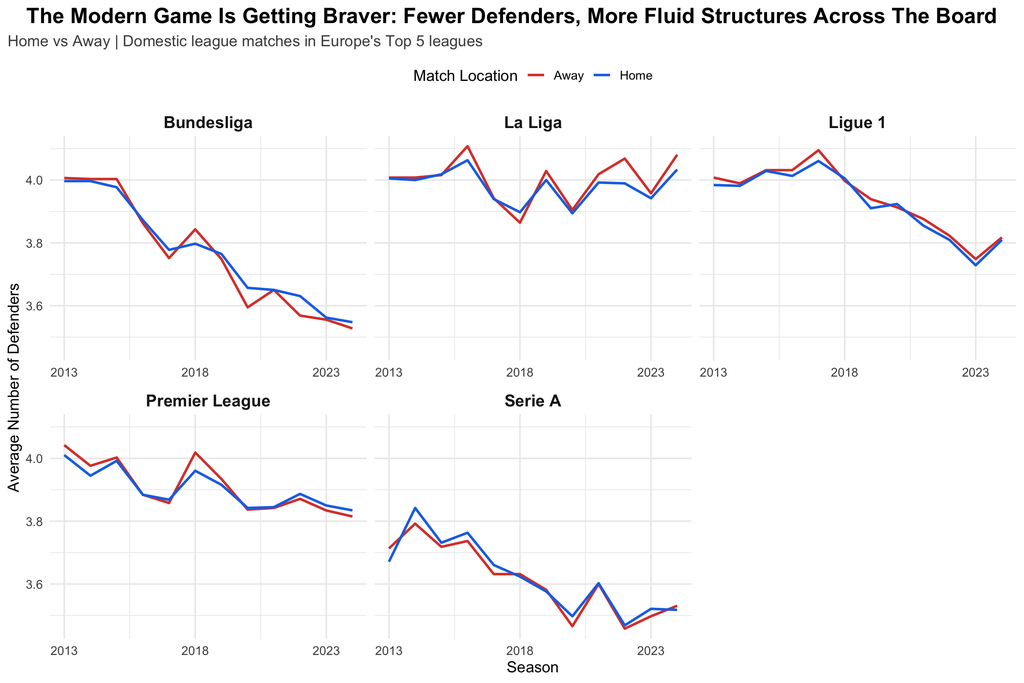

```r
extract_defenders <- function(f) {
  as.numeric(strsplit(f, "-", fixed = TRUE)[[1]][1])
}

# Vectorised version
extract_def_vec <- function(x) {
  sapply(x, function(f) {
    if (is.na(f)) return(NA_real_)
    extract_defenders(f)
  })
}

team_games_2 <- games %>%
  filter(competition_id %in% top5,
         competition_type == "domestic_league") %>%
  mutate(
    competition_id = recode(competition_id,
                            "ES1" = "La Liga",
                            "FR1" = "Ligue 1",
                            "GB1" = "Premier League",
                            "IT1" = "Serie A",
                            "L1"  = "Bundesliga")
  ) %>%
  pivot_longer(
    cols = c(home_club_formation, away_club_formation),
    names_to = "venue",
    values_to = "formation"
  ) %>%
  mutate(
    is_home   = if_else(venue == "home_club_formation", "Home", "Away"),
    defenders = extract_def_vec(formation)
  ) %>%
  filter(!is.na(defenders))

defenders_time <- team_games_2 %>%
  group_by(competition_id, season, is_home) %>%
  summarise(
    avg_def = mean(defenders, na.rm = TRUE),
    .groups = "drop"
  )

ggplot(defenders_time,
       aes(x = season, y = avg_def, color = is_home)) +
  geom_line(size = 1) +
  facet_wrap(~ competition_id, scales = "free_x") +
  scale_x_continuous(
    breaks = seq(min(defenders_time$season), max(defenders_time$season), by = 5)
  ) +
  scale_color_manual(
    name = "Match Location",
    values = c("Home" = "#1A73E8", "Away" = "#DB4437"),
    labels = c("Away", "Home")
  ) +
  labs(
    title = "The Modern Game Is Getting Braver: Fewer Defenders, More Fluid Structures Across The Board",
    subtitle = "Home vs Away | Domestic league matches in Europe's Top 5 leagues",
    x = "Season",
    y = "Average Number of Defenders"
  ) +
  theme_minimal(base_size = 13) +
  theme(
    legend.position = "top",
    strip.text = element_text(face = "bold", size = 14),
    plot.title.position = "plot",
    plot.title = element_text(hjust = 0.5, size = 18, face = "bold"),
    plot.subtitle = element_text(size = 13, color = "grey30")
  )
```

## 3.1 Interpretation

Notably, the lines for home and away teams overlap almost completely. Despite the common belief that managers adopt more defensive setups away from home, the data shows that they rarely add extra defenders. Instead, tactical caution or aggression is expressed through midfield adjustments, pressing patterns, or transition strategy rather than simply increasing the size of the defensive line.

Overall, the trend highlights a modern game that is becoming braver, more dynamic, and less dependent on traditional defensive numbers, regardless of venue.

# 4 **Risk vs Reward (Graph 3)**

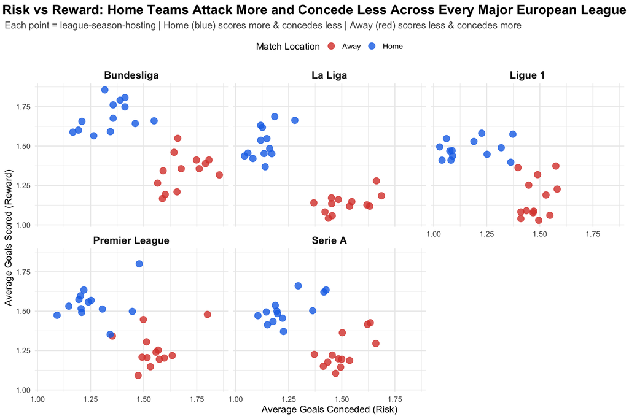

```r
# Attaching league + season to club_games
cg_merged <- club_games %>%
  left_join(
    games %>%
      select(game_id, competition_id, season),
    by = "game_id"
  ) %>%
  filter(competition_id %in% top5) %>%
  mutate(
    competition_id = recode(competition_id,
                            "ES1" = "La Liga",
                            "FR1" = "Ligue 1",
                            "GB1" = "Premier League",
                            "IT1" = "Serie A",
                            "L1"  = "Bundesliga")
  )

risk_reward <- cg_merged %>%
  mutate(
    hosting = recode(hosting,
                     "h" = "Home",
                     "a" = "Away",
                     "home" = "Home",
                     "away" = "Away")
  ) %>%
  group_by(competition_id, season, hosting) %>%
  summarise(
    avg_goals_for     = mean(own_goals, na.rm = TRUE),
    avg_goals_against = mean(opponent_goals, na.rm = TRUE),
    n_matches         = n(),
    .groups           = "drop"
  )

ggplot(risk_reward,
       aes(x = avg_goals_against,
           y = avg_goals_for,
           color = hosting)) +
  geom_point(alpha = 0.8, size = 4) +
  facet_wrap(~ competition_id) +
  scale_color_manual(
    name = "Match Location",
    values = c("Home" = "#1A73E8", "Away" = "#DB4437"),
    labels = c("Away", "Home")
  ) +
  labs(
    title = "Risk vs Reward: Home Teams Attack More and Concede Less Across Every Major European League",
    subtitle = "Each point = league-season-hosting | Home (blue) scores more & concedes less | Away (red) scores less & concedes more",
    x = "Average Goals Conceded (Risk)",
    y = "Average Goals Scored (Reward)",
    color = "Venue"
  ) +
  theme_minimal(base_size = 13) +
  theme(
    legend.position = "top",
    strip.text = element_text(face = "bold", size = 14),
    plot.title.position = "plot",
    plot.title = element_text(hjust = 0.5, size = 18, face = "bold"),
    plot.subtitle = element_text(size = 13, color = "grey30")
  )
```

## 4.1 Interpretation

This scatterplot compares attacking output (average goals scored) and defensive exposure (average goals conceded) for home and away teams across Europe’s top five leagues. Each point represents a league-season combination, allowing us to see consistent patterns over time rather than individual match noise.

The pattern is strikingly clear: home teams (blue points) cluster toward the upper-left of each panel—meaning they score more goals while conceding fewer. Away teams (red points) cluster toward the lower-right, reflecting lower attacking output and greater defensive risk. This separation holds across all leagues and seasons, providing strong evidence that home advantage consistently shapes tactical outcomes.

Overall, the graph highlights that home teams adopt more proactive, attack-minded behaviours, while away teams are forced into more defensive and reactive patterns—demonstrating a clear tactical dimension to home advantage.

# 5 **Starting XI Structure (Graph 4)**

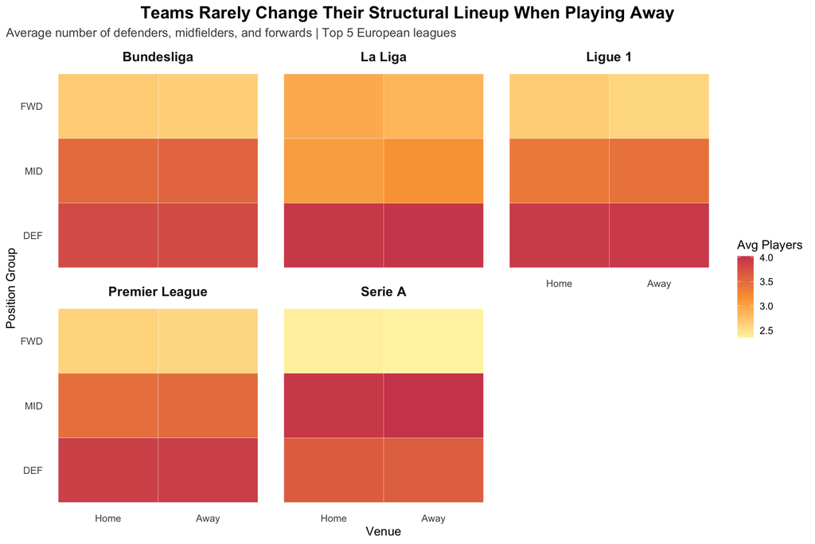

```r
# Keeping only starting XIs
starters <- lineups %>%
  filter(type == "starting_lineup") %>%
  select(game_id, club_id, player_id, position)

# Mapping detailed positions → DEF / MID / FWD / GK
categorize_pos <- function(p) {
  p <- tolower(p)

  case_when(
    str_detect(p, "goalkeeper") ~ "GK",
    str_detect(p, "back") |
      str_detect(p, "defender") |
      str_detect(p, "sweeper") |
      str_detect(p, "wing-back") ~ "DEF",
    str_detect(p, "midfield") ~ "MID",
    str_detect(p, "winger") |
      str_detect(p, "striker") |
      str_detect(p, "forward") |
      str_detect(p, "attack") ~ "FWD",
    TRUE ~ "OTHER"
  )
}

starters <- starters %>%
  mutate(position_group = categorize_pos(position))

# Building team-game table (home/away info)
team_games_4 <- games %>%
  filter(competition_id %in% top5,
         competition_type == "domestic_league") %>%
  mutate(
    competition_id = recode(competition_id,
                            "ES1" = "La Liga",
                            "FR1" = "Ligue 1",
                            "GB1" = "Premier League",
                            "IT1" = "Serie A",
                            "L1"  = "Bundesliga")
  ) %>%
  select(game_id, competition_id, home_club_id, away_club_id) %>%
  pivot_longer(
    cols = c(home_club_id, away_club_id),
    names_to = "venue",
    values_to = "club_id"
  ) %>%
  mutate(is_home = if_else(venue == "home_club_id", "Home", "Away"))

# Merging lineups with home/away + league
merged_4 <- team_games_4 %>%
  left_join(starters, by = c("game_id", "club_id")) %>%
  filter(!is.na(position_group))

# Counting players per game + position group, then average
structure <- merged_4 %>%
  group_by(competition_id, is_home, game_id, position_group) %>%
  summarise(n_players = n(), .groups = "drop") %>%
  group_by(competition_id, is_home, position_group) %>%
  summarise(avg_players = mean(n_players), .groups = "drop")

# Focusing on DEF, MID, FWD
structure_plot <- structure %>%
  filter(position_group %in% c("DEF","MID","FWD")) %>%
  mutate(
    position_group = factor(position_group, levels = c("DEF","MID","FWD")),
    is_home        = factor(is_home, levels = c("Home","Away"))
  )

ggplot(structure_plot,
       aes(x = is_home, y = position_group, fill = avg_players)) +
  geom_tile(color = "white") +
  facet_wrap(~ competition_id) +
  scale_fill_gradientn(
    colours = c("#FFF3B0", "#F9A03F", "#D1495B"),
    name = "Avg Players"
  ) +
  labs(
    title = "Teams Rarely Change Their Structural Lineup When Playing Away",
    subtitle = "Average number of defenders, midfielders, and forwards | Top 5 European leagues",
    x = "Venue",
    y = "Position Group",
    fill = "Avg Players"
  ) +
  theme_minimal(base_size = 13) +
  theme(
    panel.grid = element_blank(),
    strip.text = element_text(face = "bold", size = 14),
    plot.title.position = "plot",
    plot.title = element_text(hjust = 0.5, size = 18, face = "bold"),
    plot.subtitle = element_text(size = 13, color = "grey30")
  )
```

## 5.1 Interpretation

This heatmap compares the average number of defenders, midfielders, and forwards fielded by teams at home versus away across Europe’s top five leagues. The results show that teams maintain an almost identical structural balance regardless of venue: the number of defenders and forwards remains remarkably consistent, and midfield numbers vary only slightly between home and away matches.

This finding challenges the common assumption that away teams significantly increase defensive personnel. Instead, managers across all major European leagues appear to preserve their overall lineup structure whether playing home or away. Tactical adjustments occur within roles—such as deeper full-backs, more conservative midfield positioning, or altered pressing intensity—rather than in the raw number of players assigned to each positional group.

Overall, the heatmap reinforces that while home and away teams may differ in style and intent, their fundamental structural setup remains stable. Tactical variation comes more from movement and strategy than from altering the defender–midfielder–forward balance.

# 6 **Full Analysis Summary**

This analysis set out to answer: “How do home vs away tactical setups differ?”. Using four complementary visualisations, we find that teams differ mainly in tactical intent and behaviour, not in structural lineup composition.

# 7 **Key Conclusion**

# 8 **Behind the Scenes: Methodology**

To answer one of the sub-questions pertaining to the overall problem statement for this project, our aim was to understand how home vs away tactical setups differ across Europe’s top five leagues using the rich football dataset we selected. Methodologically, the work is primarily descriptive and exploratory, using carefully chosen visualisations rather than predictive models because the research question is about patterns of behaviour and tactical structure, not about forecasting outcomes. I used R (RStudio) with the tidyverse and ggplot2 ecosystem to build everything, as it offers a very clean pipeline for data wrangling (dplyr, tidyr) and high-quality, publication-ready graphics (ggplot2) in a fully reproducible workflow.

I started by loading the core CSV files into R (games, club_games, game_lineups) and restricting the scope to the top five European leagues (Premier League, La Liga, Serie A, Ligue 1, Bundesliga) and domestic league matches only. Because the dataset originally used competition codes (e.g. GB1, ES1), I recoded them into full league names for interpretability. From there, each of the four graphs corresponds to a slightly different slice and transformation of the data, designed to answer one piece of the home vs away question.

The first graph, the mirror bar chart, is essentially a grouped frequency comparison between home and away formations. In R, I reshaped the data from wide to long format (pivot_longer) so that home and away formations sat in the same column with a “venue” indicator. I then filtered to the top ten most frequently used formations per league, and computed relative frequencies (shares) by grouping on league, venue, and formation. Plotting these as a mirror bar chart (home shares on one side and away on the other) gives a very clear visual comparison of tactical choices by venue; this is more effective than simple side-by-side bars because it emphasises the difference around a central baseline. Statistically this is straightforward descriptive frequency analysis, but the design of the chart directly supports the question: do teams prefer different formations at home vs away?

The second graph, the defenders-over-time line chart, adds a temporal dimension and focuses on defensive structure rather than named formations. I extracted the number of defenders from each formation string (e.g. “4-2-3-1” to 4) using a small parsing function in R, then averaged this count by league, season, and venue (home vs away). This produces a time series of mean defenders per game. Plotting these as lines for home and away teams within each league allows us to see whether defensive setups differ by venue and how they evolve over time. Again, this is descriptive (grouped means over time) but conceptually it answers: are away teams actually adding defenders or has modern football shifted towards more fluid defensive roles for everyone?

The third graph, the risk-versus-reward scatterplot, moves from shape to behavioural style. Here I merged club-level match stats (club_games) with the league and season information from games, then aggregated by league, season, and hosting status to compute the average goals scored (reward) and average goals conceded (risk) for home and away teams. Plotting these aggregated points with goals conceded on the x-axis and goals scored on the y-axis produces a classic bivariate descriptive analysis: each point is a league–season–venue summary and the clustering patterns show whether home teams systematically combine higher attacking output with lower defensive exposure. This is not a formal correlation or regression model but it is a clear visual way to assess whether home vs away behaviour diverges along both dimensions simultaneously.

Finally, the fourth graph, the starting XI structure heat-map, looks at positional balance rather than nominal formations. I filtered the lineup data to starting players only, then categorised each detailed position into broad groups: defenders, midfielders, forwards (plus GK, though not plotted). By joining this with the home/away and league information from games, I could count how many defenders/midfielders/forwards each team fielded per match, and then average those counts by league and venue. The heatmap is essentially a facet-by-league matrix of mean player counts per line (DEF/MID/FWD) and venue (Home/Away). Methodologically, this is again descriptive aggregation, but it’s crucial: it tests whether structural lineups themselves change away from home or whether managers keep the same DEF–MID–FWD balance and adjust roles and behaviour instead.

Overall, the methodological choice was to use R with tidyverse + ggplot2 to build a clean, reproducible pipeline from raw CSVs to high-level tactical insights. Rather than over-complicate the analysis with regression or machine-learning models (which are better suited for prediction), I focused on carefully structured groupings, aggregations, and visual encodings that directly map onto the football concepts we care about: formation choice, defensive line depth, attacking vs defensive trade-offs, and structural lineup balance. These four visualisations together provide a coherent, statistically grounded and tactically meaningful answer to the core question of how home vs away setups differ.